# Risk Factor Analysis

## Outcome Variable

**Outcome Variable:** pers_wasted624

## Predictor Variables

**Intervention Variable:** pers_wasted06

**Adjustment Set:**

- sex
- arm
- enstunt
- month
- brthmon
- vagbrth
- single
- W_gagebrth
- W_birthwt
- W_birthlen
- W_mage
- W_mhtcm
- W_meducyrs
- W_feducyrs
- W_parity
- delta_month
- delta_brthmon
- delta_vagbrth
- delta_single
- delta_W_gagebrth
- delta_W_birthwt
- delta_W_birthlen
- delta_W_mage
- delta_W_mhtcm
- delta_W_meducyrs
- delta_W_feducyrs
- delta_W_parity

## Stratifying Variables

The analysis was stratified on these variable(s):

- studyid
- country

## Data Summary

| studyid | country | pers_wasted06 | pers_wasted624 | n_cell | n |
| --- | --- | --- | --- | --- | --- |
| ki0047075b-MAL-ED | BANGLADESH | 0 | 0 | 218 | 239 |
| ki0047075b-MAL-ED | BANGLADESH | 0 | 1 | 15 | 239 |
| ki0047075b-MAL-ED | BANGLADESH | 1 | 0 | 3 | 239 |
| ki0047075b-MAL-ED | BANGLADESH | 1 | 1 | 3 | 239 |
| ki0047075b-MAL-ED | BRAZIL | 0 | 0 | 200 | 202 |
| ki0047075b-MAL-ED | BRAZIL | 0 | 1 | 1 | 202 |
| ki0047075b-MAL-ED | BRAZIL | 1 | 0 | 0 | 202 |
| ki0047075b-MAL-ED | BRAZIL | 1 | 1 | 1 | 202 |
| ki0047075b-MAL-ED | INDIA | 0 | 0 | 198 | 234 |
| ki0047075b-MAL-ED | INDIA | 0 | 1 | 18 | 234 |
| ki0047075b-MAL-ED | INDIA | 1 | 0 | 8 | 234 |
| ki0047075b-MAL-ED | INDIA | 1 | 1 | 10 | 234 |
| ki0047075b-MAL-ED | NEPAL | 0 | 0 | 229 | 234 |
| ki0047075b-MAL-ED | NEPAL | 0 | 1 | 1 | 234 |
| ki0047075b-MAL-ED | NEPAL | 1 | 0 | 3 | 234 |
| ki0047075b-MAL-ED | NEPAL | 1 | 1 | 1 | 234 |
| ki0047075b-MAL-ED | PERU | 0 | 0 | 262 | 264 |
| ki0047075b-MAL-ED | PERU | 0 | 1 | 2 | 264 |
| ki0047075b-MAL-ED | PERU | 1 | 0 | 0 | 264 |
| ki0047075b-MAL-ED | PERU | 1 | 1 | 0 | 264 |
| ki0047075b-MAL-ED | SOUTH AFRICA | 0 | 0 | 255 | 258 |
| ki0047075b-MAL-ED | SOUTH AFRICA | 0 | 1 | 1 | 258 |
| ki0047075b-MAL-ED | SOUTH AFRICA | 1 | 0 | 1 | 258 |
| ki0047075b-MAL-ED | SOUTH AFRICA | 1 | 1 | 1 | 258 |
| ki0047075b-MAL-ED | TANZANIA, UNITED REPUBLIC OF | 0 | 0 | 244 | 244 |
| ki0047075b-MAL-ED | TANZANIA, UNITED REPUBLIC OF | 0 | 1 | 0 | 244 |
| ki0047075b-MAL-ED | TANZANIA, UNITED REPUBLIC OF | 1 | 0 | 0 | 244 |
| ki0047075b-MAL-ED | TANZANIA, UNITED REPUBLIC OF | 1 | 1 | 0 | 244 |
| ki1000108-CMC-V-BCS-2002 | INDIA | 0 | 0 | 302 | 368 |
| ki1000108-CMC-V-BCS-2002 | INDIA | 0 | 1 | 12 | 368 |

[output cut: 118 more lines]

The following strata were considered:

- studyid: ki0047075b-MAL-ED, country: BANGLADESH
- studyid: ki0047075b-MAL-ED, country: BRAZIL
- studyid: ki0047075b-MAL-ED, country: INDIA
- studyid: ki0047075b-MAL-ED, country: NEPAL
- studyid: ki0047075b-MAL-ED, country: PERU
- studyid: ki0047075b-MAL-ED, country: SOUTH AFRICA
- studyid: ki0047075b-MAL-ED, country: TANZANIA, UNITED REPUBLIC OF
- studyid: ki1000108-CMC-V-BCS-2002, country: INDIA
- studyid: ki1000108-IRC, country: INDIA
- studyid: ki1000109-EE, country: PAKISTAN
- studyid: ki1000109-ResPak, country: PAKISTAN
- studyid: ki1000304-VITAMIN-A, country: INDIA
- studyid: ki1000304b-SAS-CompFeed, country: INDIA
- studyid: ki1000304b-SAS-FoodSuppl, country: INDIA
- studyid: ki1017093-NIH-Birth, country: BANGLADESH
- studyid: ki1017093b-PROVIDE, country: BANGLADESH
- studyid: ki1017093c-NIH-Crypto, country: BANGLADESH
- studyid: ki1066203-TanzaniaChild2, country: TANZANIA, UNITED REPUBLIC OF
- studyid: ki1101329-Keneba, country: GAMBIA
- studyid: ki1112895-Burkina Faso Zn, country: BURKINA FASO
- studyid: ki1112895-Guatemala BSC, country: GUATEMALA
- studyid: ki1113344-GMS-Nepal, country: NEPAL
- studyid: ki1114097-CMIN, country: BANGLADESH
- studyid: ki1114097-CMIN, country: BRAZIL
- studyid: ki1114097-CMIN, country: GUINEA-BISSAU
- studyid: ki1114097-CMIN, country: PERU
- studyid: ki1114097-CONTENT, country: PERU
- studyid: ki1119695-PROBIT, country: BELARUS
- studyid: ki1126311-ZVITAMBO, country: ZIMBABWE
- studyid: ki1135781-COHORTS, country: GUATEMALA
- studyid: ki1135781-COHORTS, country: INDIA
- studyid: ki1135781-COHORTS, country: PHILIPPINES
- studyid: ki1148112-iLiNS-DOSE, country: MALAWI
- studyid: ki1148112-iLiNS-DYAD-M, country: MALAWI
- studyid: ki1148112-LCNI-5, country: MALAWI
- studyid: kiGH5241-JiVitA-3, country: BANGLADESH
- studyid: kiGH5241-JiVitA-4, country: BANGLADESH

### Dropped Strata

Some strata were dropped due to rare outcomes:

- studyid: ki0047075b-MAL-ED, country: BANGLADESH
- studyid: ki0047075b-MAL-ED, country: BRAZIL
- studyid: ki0047075b-MAL-ED, country: NEPAL
- studyid: ki0047075b-MAL-ED, country: PERU
- studyid: ki0047075b-MAL-ED, country: SOUTH AFRICA
- studyid: ki0047075b-MAL-ED, country: TANZANIA, UNITED REPUBLIC OF
- studyid: ki1017093c-NIH-Crypto, country: BANGLADESH
- studyid: ki1112895-Burkina Faso Zn, country: BURKINA FASO
- studyid: ki1112895-Guatemala BSC, country: GUATEMALA
- studyid: ki1114097-CMIN, country: BANGLADESH
- studyid: ki1114097-CMIN, country: BRAZIL
- studyid: ki1114097-CMIN, country: PERU
- studyid: ki1114097-CONTENT, country: PERU
- studyid: ki1148112-iLiNS-DOSE, country: MALAWI
- studyid: ki1148112-iLiNS-DYAD-M, country: MALAWI
- studyid: ki1148112-LCNI-5, country: MALAWI

## Methods Detail

We’re interested in the causal parameters $E[Y_a]$ for all values of $a \in \mathcal{A}$. These parameters represent the mean outcome if, possibly contrary to fact, we intervened to set all units to have $A=a$. Under the randomization and positivity assumptions, these are identified by the statistical parameters $\psi_a=E_W[E_{Y|A,W}(Y|A=a,W)]$. In addition, we’re interested in the mean of $Y$, $E[Y]$ under no intervention (the observed mean). We will estimate these parameters by using SuperLearner to fit the relevant likelihood factors – $E_{Y|A,W}(Y|A=a,W)$ and $p(A=a|W)$, and then updating our likelihood fit using a joint TMLE.

For unadjusted analyses ($W=\{\}$), initial likelihoods were estimated using Lrnr_glm to estimate the simple $E(Y|A)$ and Lrnr_mean to estimate $p(A)$. For adjusted analyses, a small library containing Lrnr_glmnet, Lrnr_xgboost, and Lrnr_mean was used.

Having estimated these parameters, we will then use the delta method to estimate relative risks and attributable risks relative to a prespecified baseline level of $A$.

# Results Detail

## Results Plots

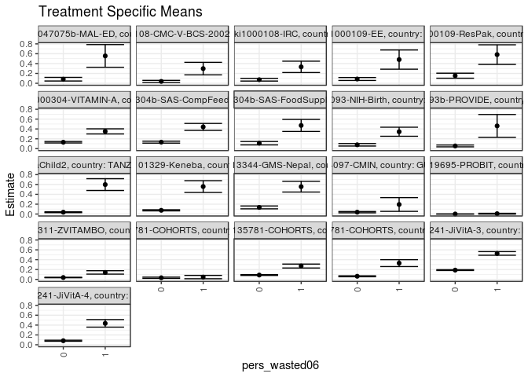

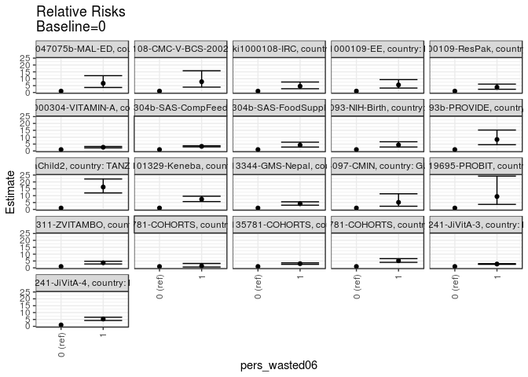

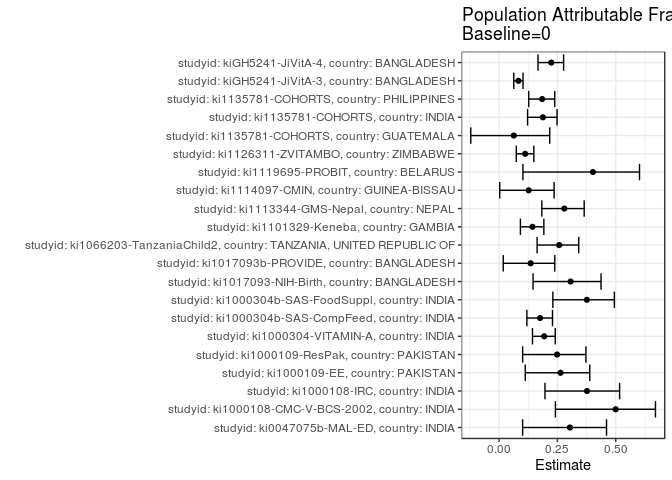

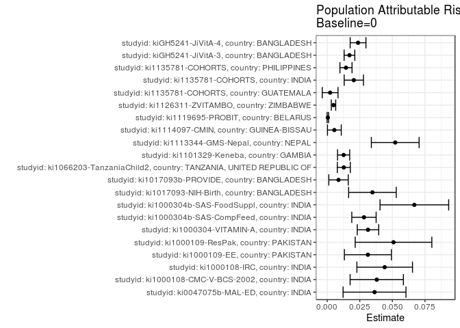

## Results Table

### Parameter: TSM

| studyid | country | intervention_level | baseline_level | estimate | ci_lower | ci_upper |
| --- | --- | --- | --- | --- | --- | --- |
| ki0047075b-MAL-ED | INDIA | 0 | NA | 0.0833333 | 0.0463959 | 0.1202707 |
| ki0047075b-MAL-ED | INDIA | 1 | NA | 0.5555556 | 0.3255098 | 0.7856013 |
| ki1000108-CMC-V-BCS-2002 | INDIA | 0 | NA | 0.0380601 | 0.0167858 | 0.0593344 |
| ki1000108-CMC-V-BCS-2002 | INDIA | 1 | NA | 0.2981935 | 0.1711381 | 0.4252488 |
| ki1000108-IRC | INDIA | 0 | NA | 0.0729574 | 0.0453553 | 0.1005594 |
| ki1000108-IRC | INDIA | 1 | NA | 0.3334213 | 0.2182939 | 0.4485486 |
| ki1000109-EE | PAKISTAN | 0 | NA | 0.0873686 | 0.0574280 | 0.1173091 |
| ki1000109-EE | PAKISTAN | 1 | NA | 0.4813015 | 0.2860666 | 0.6765363 |
| ki1000109-ResPak | PAKISTAN | 0 | NA | 0.1536607 | 0.1027771 | 0.2045442 |
| ki1000109-ResPak | PAKISTAN | 1 | NA | 0.5824223 | 0.3831837 | 0.7816610 |
| ki1000304-VITAMIN-A | INDIA | 0 | NA | 0.1304414 | 0.1155848 | 0.1452979 |
| ki1000304-VITAMIN-A | INDIA | 1 | NA | 0.3506802 | 0.2986579 | 0.4027026 |
| ki1000304b-SAS-CompFeed | INDIA | 0 | NA | 0.1321442 | 0.1123855 | 0.1519029 |
| ki1000304b-SAS-CompFeed | INDIA | 1 | NA | 0.4412594 | 0.3705268 | 0.5119919 |
| ki1000304b-SAS-FoodSuppl | INDIA | 0 | NA | 0.1109576 | 0.0764144 | 0.1455007 |
| ki1000304b-SAS-FoodSuppl | INDIA | 1 | NA | 0.4712203 | 0.3489025 | 0.5935382 |
| ki1017093-NIH-Birth | BANGLADESH | 0 | NA | 0.0785675 | 0.0531649 | 0.1039701 |
| ki1017093-NIH-Birth | BANGLADESH | 1 | NA | 0.3435530 | 0.2516654 | 0.4354407 |
| ki1017093b-PROVIDE | BANGLADESH | 0 | NA | 0.0554622 | 0.0369881 | 0.0739363 |
| ki1017093b-PROVIDE | BANGLADESH | 1 | NA | 0.4615385 | 0.2295775 | 0.6934994 |
| ki1066203-TanzaniaChild2 | TANZANIA, UNITED REPUBLIC OF | 0 | NA | 0.0367172 | 0.0281708 | 0.0452636 |
| ki1066203-TanzaniaChild2 | TANZANIA, UNITED REPUBLIC OF | 1 | NA | 0.5974614 | 0.4778077 | 0.7171152 |
| ki1101329-Keneba | GAMBIA | 0 | NA | 0.0753215 | 0.0640844 | 0.0865586 |
| ki1101329-Keneba | GAMBIA | 1 | NA | 0.5577328 | 0.4383269 | 0.6771387 |
| ki1113344-GMS-Nepal | NEPAL | 0 | NA | 0.1344354 | 0.1048678 | 0.1640030 |
| ki1113344-GMS-Nepal | NEPAL | 1 | NA | 0.5555546 | 0.4467246 | 0.6643847 |
| ki1114097-CMIN | GUINEA-BISSAU | 0 | NA | 0.0377358 | 0.0249030 | 0.0505687 |
| ki1114097-CMIN | GUINEA-BISSAU | 1 | NA | 0.1935484 | 0.0543935 | 0.3327032 |
| ki1119695-PROBIT | BELARUS | 0 | NA | 0.0007270 | 0.0001693 | 0.0012847 |
| ki1119695-PROBIT | BELARUS | 1 | NA | 0.0068285 | -0.0005804 | 0.0142374 |
| ki1126311-ZVITAMBO | ZIMBABWE | 0 | NA | 0.0383668 | 0.0341835 | 0.0425501 |
| ki1126311-ZVITAMBO | ZIMBABWE | 1 | NA | 0.1415113 | 0.1070770 | 0.1759457 |
| ki1135781-COHORTS | GUATEMALA | 0 | NA | 0.0334225 | 0.0205347 | 0.0463102 |
| ki1135781-COHORTS | GUATEMALA | 1 | NA | 0.0469799 | 0.0129857 | 0.0809740 |
| ki1135781-COHORTS | INDIA | 0 | NA | 0.0883351 | 0.0801941 | 0.0964762 |
| ki1135781-COHORTS | INDIA | 1 | NA | 0.2709899 | 0.2312226 | 0.3107571 |
| ki1135781-COHORTS | PHILIPPINES | 0 | NA | 0.0635944 | 0.0541906 | 0.0729981 |
| ki1135781-COHORTS | PHILIPPINES | 1 | NA | 0.3300696 | 0.2599632 | 0.4001760 |
| kiGH5241-JiVitA-3 | BANGLADESH | 0 | NA | 0.1885687 | 0.1803438 | 0.1967936 |
| kiGH5241-JiVitA-3 | BANGLADESH | 1 | NA | 0.5272041 | 0.4905455 | 0.5638628 |
| kiGH5241-JiVitA-4 | BANGLADESH | 0 | NA | 0.0821893 | 0.0715629 | 0.0928157 |
| kiGH5241-JiVitA-4 | BANGLADESH | 1 | NA | 0.4347308 | 0.3581621 | 0.5112995 |

### Parameter: E(Y)

| studyid | country | intervention_level | baseline_level | estimate | ci_lower | ci_upper |
| --- | --- | --- | --- | --- | --- | --- |
| ki0047075b-MAL-ED | INDIA | NA | NA | 0.1196581 | 0.0779840 | 0.1613323 |
| ki1000108-CMC-V-BCS-2002 | INDIA | NA | NA | 0.0760870 | 0.0489610 | 0.1032130 |
| ki1000108-IRC | INDIA | NA | NA | 0.1170732 | 0.0859146 | 0.1482317 |
| ki1000109-EE | PAKISTAN | NA | NA | 0.1185984 | 0.0856546 | 0.1515422 |
| ki1000109-ResPak | PAKISTAN | NA | NA | 0.2045455 | 0.1511224 | 0.2579685 |
| ki1000304-VITAMIN-A | INDIA | NA | NA | 0.1617391 | 0.1466878 | 0.1767905 |
| ki1000304b-SAS-CompFeed | INDIA | NA | NA | 0.1603563 | 0.1395035 | 0.1812092 |
| ki1000304b-SAS-FoodSuppl | INDIA | NA | NA | 0.1778351 | 0.1397389 | 0.2159312 |
| ki1017093-NIH-Birth | BANGLADESH | NA | NA | 0.1132813 | 0.0858017 | 0.1407608 |
| ki1017093b-PROVIDE | BANGLADESH | NA | NA | 0.0641447 | 0.0446535 | 0.0836359 |
| ki1066203-TanzaniaChild2 | TANZANIA, UNITED REPUBLIC OF | NA | NA | 0.0494534 | 0.0397554 | 0.0591514 |
| ki1101329-Keneba | GAMBIA | NA | NA | 0.0879121 | 0.0760335 | 0.0997906 |
| ki1113344-GMS-Nepal | NEPAL | NA | NA | 0.1866438 | 0.1550166 | 0.2182711 |
| ki1114097-CMIN | GUINEA-BISSAU | NA | NA | 0.0432309 | 0.0297785 | 0.0566834 |
| ki1119695-PROBIT | BELARUS | NA | NA | 0.0012159 | 0.0002433 | 0.0021885 |
| ki1126311-ZVITAMBO | ZIMBABWE | NA | NA | 0.0432128 | 0.0388939 | 0.0475316 |
| ki1135781-COHORTS | GUATEMALA | NA | NA | 0.0356745 | 0.0235298 | 0.0478191 |
| ki1135781-COHORTS | INDIA | NA | NA | 0.1087695 | 0.1008135 | 0.1167256 |
| ki1135781-COHORTS | PHILIPPINES | NA | NA | 0.0780116 | 0.0679971 | 0.0880261 |
| kiGH5241-JiVitA-3 | BANGLADESH | NA | NA | 0.2056528 | 0.1980793 | 0.2132263 |
| kiGH5241-JiVitA-4 | BANGLADESH | NA | NA | 0.1058706 | 0.0951082 | 0.1166330 |

### Parameter: RR

| studyid | country | intervention_level | baseline_level | estimate | ci_lower | ci_upper |
| --- | --- | --- | --- | --- | --- | --- |
| ki0047075b-MAL-ED | INDIA | 0 | 0 | 1.000000 | 1.0000000 | 1.000000 |
| ki0047075b-MAL-ED | INDIA | 1 | 0 | 6.666667 | 3.6347655 | 12.227596 |
| ki1000108-CMC-V-BCS-2002 | INDIA | 0 | 0 | 1.000000 | 1.0000000 | 1.000000 |
| ki1000108-CMC-V-BCS-2002 | INDIA | 1 | 0 | 7.834803 | 3.8802902 | 15.819473 |
| ki1000108-IRC | INDIA | 0 | 0 | 1.000000 | 1.0000000 | 1.000000 |
| ki1000108-IRC | INDIA | 1 | 0 | 4.570083 | 2.7397295 | 7.623257 |
| ki1000109-EE | PAKISTAN | 0 | 0 | 1.000000 | 1.0000000 | 1.000000 |
| ki1000109-EE | PAKISTAN | 1 | 0 | 5.508863 | 3.2376740 | 9.373265 |
| ki1000109-ResPak | PAKISTAN | 0 | 0 | 1.000000 | 1.0000000 | 1.000000 |
| ki1000109-ResPak | PAKISTAN | 1 | 0 | 3.790315 | 2.3555807 | 6.098915 |
| ki1000304-VITAMIN-A | INDIA | 0 | 0 | 1.000000 | 1.0000000 | 1.000000 |
| ki1000304-VITAMIN-A | INDIA | 1 | 0 | 2.688413 | 2.2312467 | 3.239249 |
| ki1000304b-SAS-CompFeed | INDIA | 0 | 0 | 1.000000 | 1.0000000 | 1.000000 |
| ki1000304b-SAS-CompFeed | INDIA | 1 | 0 | 3.339227 | 2.9639571 | 3.762011 |
| ki1000304b-SAS-FoodSuppl | INDIA | 0 | 0 | 1.000000 | 1.0000000 | 1.000000 |
| ki1000304b-SAS-FoodSuppl | INDIA | 1 | 0 | 4.246852 | 2.8298759 | 6.373338 |
| ki1017093-NIH-Birth | BANGLADESH | 0 | 0 | 1.000000 | 1.0000000 | 1.000000 |
| ki1017093-NIH-Birth | BANGLADESH | 1 | 0 | 4.372713 | 2.8673091 | 6.668489 |
| ki1017093b-PROVIDE | BANGLADESH | 0 | 0 | 1.000000 | 1.0000000 | 1.000000 |
| ki1017093b-PROVIDE | BANGLADESH | 1 | 0 | 8.321678 | 4.5536120 | 15.207780 |
| ki1066203-TanzaniaChild2 | TANZANIA, UNITED REPUBLIC OF | 0 | 0 | 1.000000 | 1.0000000 | 1.000000 |
| ki1066203-TanzaniaChild2 | TANZANIA, UNITED REPUBLIC OF | 1 | 0 | 16.271974 | 11.9691355 | 22.121659 |
| ki1101329-Keneba | GAMBIA | 0 | 0 | 1.000000 | 1.0000000 | 1.000000 |
| ki1101329-Keneba | GAMBIA | 1 | 0 | 7.404698 | 5.7041181 | 9.612274 |
| ki1113344-GMS-Nepal | NEPAL | 0 | 0 | 1.000000 | 1.0000000 | 1.000000 |
| ki1113344-GMS-Nepal | NEPAL | 1 | 0 | 4.132502 | 3.0842856 | 5.536961 |
| ki1114097-CMIN | GUINEA-BISSAU | 0 | 0 | 1.000000 | 1.0000000 | 1.000000 |
| ki1114097-CMIN | GUINEA-BISSAU | 1 | 0 | 5.129032 | 2.3153952 | 11.361763 |
| ki1119695-PROBIT | BELARUS | 0 | 0 | 1.000000 | 1.0000000 | 1.000000 |
| ki1119695-PROBIT | BELARUS | 1 | 0 | 9.392951 | 3.6435746 | 24.214551 |
| ki1126311-ZVITAMBO | ZIMBABWE | 0 | 0 | 1.000000 | 1.0000000 | 1.000000 |
| ki1126311-ZVITAMBO | ZIMBABWE | 1 | 0 | 3.688381 | 2.8254312 | 4.814894 |
| ki1135781-COHORTS | GUATEMALA | 0 | 0 | 1.000000 | 1.0000000 | 1.000000 |
| ki1135781-COHORTS | GUATEMALA | 1 | 0 | 1.405638 | 0.6191362 | 3.191248 |
| ki1135781-COHORTS | INDIA | 0 | 0 | 1.000000 | 1.0000000 | 1.000000 |
| ki1135781-COHORTS | INDIA | 1 | 0 | 3.067748 | 2.5807962 | 3.646578 |
| ki1135781-COHORTS | PHILIPPINES | 0 | 0 | 1.000000 | 1.0000000 | 1.000000 |
| ki1135781-COHORTS | PHILIPPINES | 1 | 0 | 5.190233 | 4.0110201 | 6.716128 |
| kiGH5241-JiVitA-3 | BANGLADESH | 0 | 0 | 1.000000 | 1.0000000 | 1.000000 |
| kiGH5241-JiVitA-3 | BANGLADESH | 1 | 0 | 2.795820 | 2.5764028 | 3.033924 |
| kiGH5241-JiVitA-4 | BANGLADESH | 0 | 0 | 1.000000 | 1.0000000 | 1.000000 |
| kiGH5241-JiVitA-4 | BANGLADESH | 1 | 0 | 5.289385 | 4.2523718 | 6.579292 |

### Parameter: PAR

| studyid | country | intervention_level | baseline_level | estimate | ci_lower | ci_upper |
| --- | --- | --- | --- | --- | --- | --- |
| ki0047075b-MAL-ED | INDIA | 0 | NA | 0.0363248 | 0.0121946 | 0.0604550 |
| ki1000108-CMC-V-BCS-2002 | INDIA | 0 | NA | 0.0380268 | 0.0175917 | 0.0584620 |
| ki1000108-IRC | INDIA | 0 | NA | 0.0441158 | 0.0227768 | 0.0654548 |
| ki1000109-EE | PAKISTAN | 0 | NA | 0.0312298 | 0.0131862 | 0.0492735 |
| ki1000109-ResPak | PAKISTAN | 0 | NA | 0.0508848 | 0.0214728 | 0.0802968 |
| ki1000304-VITAMIN-A | INDIA | 0 | NA | 0.0312978 | 0.0230592 | 0.0395364 |
| ki1000304b-SAS-CompFeed | INDIA | 0 | NA | 0.0282122 | 0.0188785 | 0.0375459 |
| ki1000304b-SAS-FoodSuppl | INDIA | 0 | NA | 0.0668775 | 0.0405339 | 0.0932211 |
| ki1017093-NIH-Birth | BANGLADESH | 0 | NA | 0.0347138 | 0.0164546 | 0.0529729 |
| ki1017093b-PROVIDE | BANGLADESH | 0 | NA | 0.0086826 | 0.0012208 | 0.0161443 |
| ki1066203-TanzaniaChild2 | TANZANIA, UNITED REPUBLIC OF | 0 | NA | 0.0127362 | 0.0077446 | 0.0177279 |
| ki1101329-Keneba | GAMBIA | 0 | NA | 0.0125906 | 0.0079217 | 0.0172595 |
| ki1113344-GMS-Nepal | NEPAL | 0 | NA | 0.0522084 | 0.0338681 | 0.0705488 |
| ki1114097-CMIN | GUINEA-BISSAU | 0 | NA | 0.0054951 | 0.0002127 | 0.0107775 |
| ki1119695-PROBIT | BELARUS | 0 | NA | 0.0004889 | -0.0000743 | 0.0010521 |
| ki1126311-ZVITAMBO | ZIMBABWE | 0 | NA | 0.0048460 | 0.0031589 | 0.0065331 |
| ki1135781-COHORTS | GUATEMALA | 0 | NA | 0.0022520 | -0.0037959 | 0.0083000 |
| ki1135781-COHORTS | INDIA | 0 | NA | 0.0204344 | 0.0130483 | 0.0278206 |
| ki1135781-COHORTS | PHILIPPINES | 0 | NA | 0.0144172 | 0.0097718 | 0.0190627 |
| kiGH5241-JiVitA-3 | BANGLADESH | 0 | NA | 0.0170841 | 0.0129877 | 0.0211806 |
| kiGH5241-JiVitA-4 | BANGLADESH | 0 | NA | 0.0236814 | 0.0176262 | 0.0297366 |

### Parameter: PAF

| studyid | country | intervention_level | baseline_level | estimate | ci_lower | ci_upper |
| --- | --- | --- | --- | --- | --- | --- |
| ki0047075b-MAL-ED | INDIA | 0 | NA | 0.3035714 | 0.1010431 | 0.4604716 |
| ki1000108-CMC-V-BCS-2002 | INDIA | 0 | NA | 0.4997815 | 0.2414436 | 0.6701384 |
| ki1000108-IRC | INDIA | 0 | NA | 0.3768225 | 0.1967749 | 0.5165113 |
| ki1000109-EE | PAKISTAN | 0 | NA | 0.2633242 | 0.1123300 | 0.3886340 |
| ki1000109-ResPak | PAKISTAN | 0 | NA | 0.2487701 | 0.1010831 | 0.3721929 |
| ki1000304-VITAMIN-A | INDIA | 0 | NA | 0.1935078 | 0.1432850 | 0.2407864 |
| ki1000304b-SAS-CompFeed | INDIA | 0 | NA | 0.1759343 | 0.1191907 | 0.2290224 |
| ki1000304b-SAS-FoodSuppl | INDIA | 0 | NA | 0.3760648 | 0.2305245 | 0.4940772 |
| ki1017093-NIH-Birth | BANGLADESH | 0 | NA | 0.3064389 | 0.1456063 | 0.4369960 |
| ki1017093b-PROVIDE | BANGLADESH | 0 | NA | 0.1353588 | 0.0179429 | 0.2387362 |
| ki1066203-TanzaniaChild2 | TANZANIA, UNITED REPUBLIC OF | 0 | NA | 0.2575395 | 0.1631025 | 0.3413200 |
| ki1101329-Keneba | GAMBIA | 0 | NA | 0.1432181 | 0.0915576 | 0.1919408 |
| ki1113344-GMS-Nepal | NEPAL | 0 | NA | 0.2797221 | 0.1832954 | 0.3647639 |
| ki1114097-CMIN | GUINEA-BISSAU | 0 | NA | 0.1271102 | 0.0028857 | 0.2358584 |
| ki1119695-PROBIT | BELARUS | 0 | NA | 0.4020917 | 0.1022350 | 0.6017952 |
| ki1126311-ZVITAMBO | ZIMBABWE | 0 | NA | 0.1121422 | 0.0737902 | 0.1489062 |
| ki1135781-COHORTS | GUATEMALA | 0 | NA | 0.0631267 | -0.1211887 | 0.2171419 |
| ki1135781-COHORTS | INDIA | 0 | NA | 0.1878690 | 0.1222572 | 0.2485762 |
| ki1135781-COHORTS | PHILIPPINES | 0 | NA | 0.1848089 | 0.1272499 | 0.2385719 |
| kiGH5241-JiVitA-3 | BANGLADESH | 0 | NA | 0.0830726 | 0.0630226 | 0.1026936 |
| kiGH5241-JiVitA-4 | BANGLADESH | 0 | NA | 0.2236821 | 0.1669465 | 0.2765537 |